# 1.7 1.8 自定义R函数与控制流

授课教师: 李哲源，河南大学数学与统计学院

最后修改日期: 2023-03-13

R软件： 初学**R**语言可以不用安装该软件，不妨试试在线版本：https://rdrr.io/snippets/。

R程序文件：创建一个后缀名为”.R”的文件，比如”example.R”，然后用普通的记事本（notepad）打开。或者，安装一个更高级的记事本（[notepad++](https://github.com/notepad-plus-plus/notepad-plus-plus/releases/latest)）以获得更好的编程体验。

外部数据：本节所需的外部数据可从https://github.com/ZheyuanLi/statistical-modeling-with-R/tree/main/data/chap1获取。

# 1.8 自定义R函数

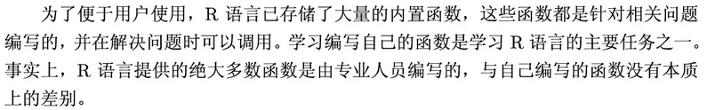

## 1.8.1 函数的定义

函数的定义格式如下：

```r
funname <- function (arg1, arg2, ...) {
  expression
}
```

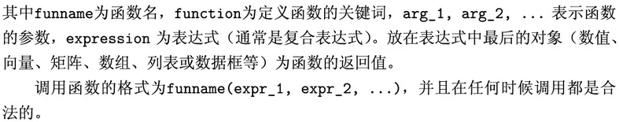

注意事项：

1. 谨慎处理函数的返回值（见后续例子）；
2. 建立好的习惯：在程序文件（即”.R”文件）中编写函数，使用时粘贴进R程序窗口。

### 1.8.1-1 无参数函数

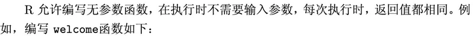

```r
## 定义
welcome <- function () {
  print("Welcome to use R!")
}

## 调用
welcome()
## [1] "Welcome to use R!"
```

更清爽的打印函数是`cat`。

```r
## 定义
welcome <- function () {
  cat("Welcome to use R!\n")
}

## 调用
welcome()
## Welcome to use R!
```

稍后我们会再介绍`cat`函数的使用。

### 1.8.1-2 带有参数的函数

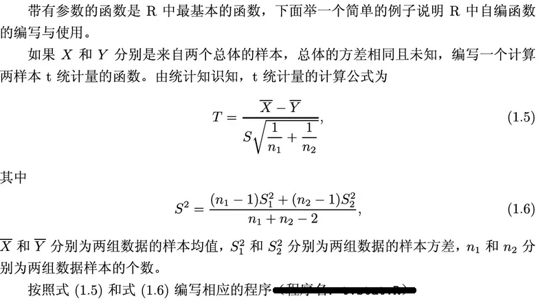

```r
t.stat <- function (x, y) {
  n1 <- length(x); n2 <- length(y)
  ## 样本均值x.bar和y.bar
  xb <- mean(x); yb <- mean(y)
  ## 样本方差S1方和S2方
  Sx2 <- var(x); Sy2 <- var(y)
  ## (1.6)
  S2 <- ((n1 - 1) * Sx2 + (n2 - 1) * Sy2) / (n1 + n2 - 2)
  ## (1.5)
  (xb - yb) / sqrt(S2 * (1 / n1 + 1 / n2))
}
```

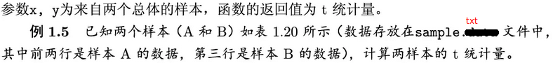

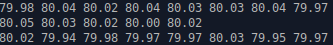

```r
x <- scan("sample.txt", what = 0, nlines = 2)
y <- scan("sample.txt", what = 0, skip = 2)
t.stat(x, y)
## [1] 3.472245
```

写函数的一个好处是不会在**R**环境中放入太多临时变量。函数内部生成的变量都是临时变量，在函数执行完毕后会被清除。

```r
## 找不到xb、yb等这些临时变量
ls()
## [1] "t.stat"  "welcome" "x"       "y"
```

## 1.8.2 参数传递与参数的默认值

参数值可以对位传递，也可以由参数名引导传递。

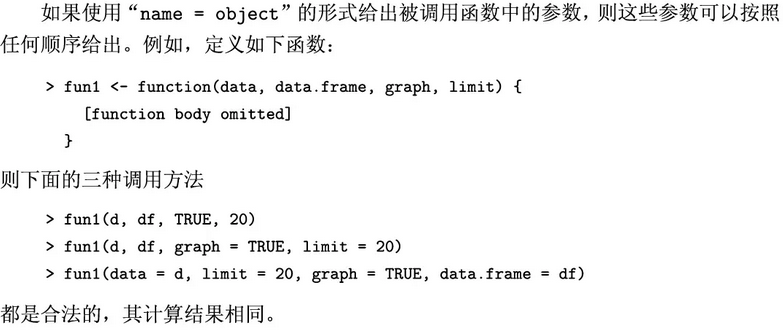

例如，以下调用`t.stat`的方法等价：

[figure not shown]

```r
t.stat(x, y)
## [1] 3.472245

t.stat(x = x, y = y)
## [1] 3.472245

t.stat(y = y, x = x)
## [1] 3.472245
```

```r
moment <- function(x, k, mean = 0) {
  sum((x - mean) ^ k) / length(x)
}
```

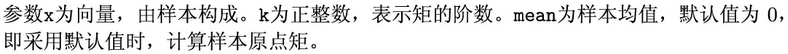

```r
moment(x, k = 2)
## [1] 6403.324

moment(x, k = 2, mean = mean(x))
## [1] 0.0005301775
```

谨慎处理函数的返回值！不想隐藏返回值，函数的最后一个语句就不要做赋值(`<-`)。

```r
moment_hide <- function(x, k, mean = 0) {
  ans <- sum((x - mean) ^ k) / length(x)
}

## 没有显示结果
moment_hide(x, k = 2)

## 获取函数结果
jieguo <- moment_hide(x, k = 2)
jieguo
## [1] 6403.324
```

## 1.8.3 递归函数

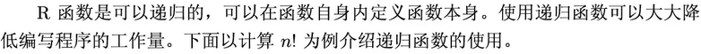

```r
## 定义
fac <- function (n) {
  if (n <= 1) {  ## 退出机制
    ans <- 1
  } else {  ## “转圈圈”
    ans <- n * fac(n - 1)
  }
  ans
}

## 调用
fac(5)
## [1] 120
```

当函数内有`if`、`else`、循环等其它包含`{`和`}`的语句时，容易忘记给函数返回值。

```r
fac_hide <- function (n) {
  if (n <= 1) {
    ans <- 1
  } else {
    ans <- n * fac(n - 1)
  }
}

fac_hide(5)
```

提示：**R**有自己的阶乘函数`factorial`.

# 1.7 控制流

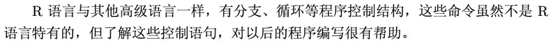

## 准备工作：逻辑值的运算

介绍`&`（“与”）， `|`（“或”）， `!`（“非”），`all`（全真）和`any`（任意真）。

“与”运算表

```
##       T     F
## T  TRUE FALSE
## F FALSE FALSE
```

“或”运算表

```
##      T     F
## T TRUE  TRUE
## F TRUE FALSE
```

“非”运算表

```
##     T     F
## FALSE  TRUE
```

```r
x <- c(TRUE, FALSE, TRUE, FALSE)
y <- c(TRUE, TRUE, FALSE, FALSE)

x & y
## [1]  TRUE FALSE FALSE FALSE

x | y
## [1]  TRUE  TRUE  TRUE FALSE

!x
## [1] FALSE  TRUE FALSE  TRUE

all(x)
## [1] FALSE

any(x)
## [1] TRUE
```

## 1.7.1 分支函数

### 1.7.1-1 `if/else`函数

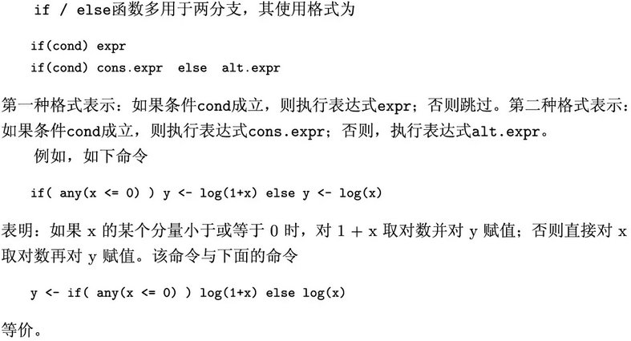

注意：`cond`只能明确接收一个TRUE或者FALSE，否则（自**R** 4.2.0起）会报错（以前的**R**版本只是报警告）。

```r
if (c(TRUE, FALSE)) cat("Hi!\n")
## Error in if (c(TRUE, FALSE)) cat("Hi!\n"): the condition has length > 1
```

用`if`和`else`判断一个数是奇数还是偶数。（以下，`%%`是求除法余数的运算；`==`是判断是否相等；`!=`是判断是否不等）。

```r
oddeven <- function (n) {
  if (n %% 2 == 0) {
    cat(n, "是偶数。\n")
  } else {
    cat(n, "是奇数。\n")
  }
}

oddeven(3)
## 3 是奇数。

oddeven(10)
## 10 是偶数。
```

### 1.7.1-2 `switch`函数

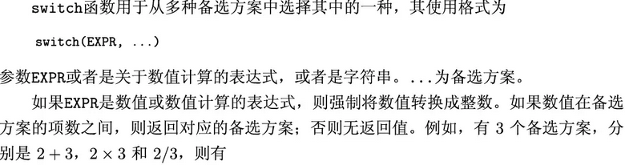

[figure not shown]

```r
switch(1, 2 + 3, 2 * 3, 2 / 3)
## [1] 5

switch(1 + 1, 2 + 3, 2 * 3, 2 / 3)
## [1] 6

switch(1 + 1 * 2, 2 + 3, 2 * 3, 2 / 3)
## [1] 0.6666667
```

```r
x <- c(1:8, 100)

type <- "mean"
switch (type, mean = mean(x), median = median(x), trimmed = mean(x, trim = 0.2))
## [1] 15.11111

type <- "median"
switch (type, mean = mean(x), median = median(x), trimmed = mean(x, trim = 0.2))
## [1] 5

type <- "trimmed"
switch (type, mean = mean(x), median = median(x), trimmed = mean(x, trim = 0.2))
## [1] 5
```

## 1.7.2 中止语句和空语句

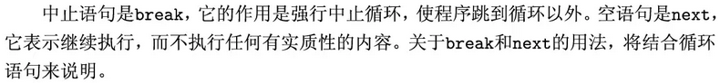

## 1.7.3 循环函数

循环函数有`for`，`while`和`repeat`。

### 1.7.3-1 `for`循环

`for`循环的结构为：

```r
for (var in seq) {
  expr
}
```

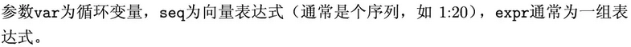

例如，可以用一层循环创建一个向量$x_i = i ^ 2,\ i = 1, 2, \ldots, n$.

```r
n <- 10
x <- rep(0, n)
for (i in 1:n) {
  x[i] <- i ^ 2
}
x
##  [1]   1   4   9  16  25  36  49  64  81 100
```

可以用一层循环计算阶乘$n!$.

```r
fac <- function (n) {
  f <- 1
  if (n >= 1) {
    for(i in 1:n) {
      f <- f * i
    }
  }
  f
}

fac(5)
## [1] 120
```

可以用一层循环计算递推数列，如Fibonacci数列（满足递推关系式$f_{i + 2} = f_{i + 1} + f_i,\ f_1 = f_2 = 1$）。

```r
fibonacci <- function (start, length) {
  if (length <= 2) stop("数列需要至少3项！")  ## 用stop函数发出错误提示
  f <- rep(0, length)
  f[1:2] <- start
  for (i in 3:length) {
    f[i] <- f[i - 1] + f[i - 2]
  }
  f
}

## Fibonacci数列的前10项
fibonacci(c(1, 1), 10)
##  [1]  1  1  2  3  5  8 13 21 34 55
```

可以用一层循环生成一个向量的多项式设计矩阵。

```r
polyX <- function (x, p) {
  n <- length(x)
  X <- matrix(0, nrow = n, ncol = p + 1)
  for (j in 0:p) {
    X[, j + 1] <- x ^ j
  }
  X
}

polyX(1:4, 3)
##      [,1] [,2] [,3] [,4]
## [1,]    1    1    1    1
## [2,]    1    2    4    8
## [3,]    1    3    9   27
## [4,]    1    4   16   64
```

循环可以嵌套，比如，可以用两层循环创建一个$n$阶的Hilbert矩阵$H_{ij} = \frac{1}{i + j - 1}$.

```r
Hilbert <- function (n) {
  H <- matrix(0, nrow = n, ncol = n)
  for (j in 1:n) {
    for (i in 1:n) {
      H[i, j] <- 1 / (i + j - 1)
    }
  }
  H
}

Hilbert(4)
##           [,1]      [,2]      [,3]      [,4]
## [1,] 1.0000000 0.5000000 0.3333333 0.2500000
## [2,] 0.5000000 0.3333333 0.2500000 0.2000000
## [3,] 0.3333333 0.2500000 0.2000000 0.1666667
## [4,] 0.2500000 0.2000000 0.1666667 0.1428571
```

### 1.7.3-2 `while`循环

当循环的次数不能事先确定时，通常使用`while`循环，其结构为：

```r
while (cond) expr
```

假如我们在重复她投掷一个均匀的六面骰子，直到所得数字的和超过20，我们可以写一个`while`循环来模拟这个过程。

```r
## 和的初始值为0，投掷次数的初始值也为0
dice_sum <- 0
i <- 0
## while循环
while (dice_sum <= 20) {
  dice_sum <- dice_sum + sample(6, 1)
  i <- i + 1
}
## 一次随机试验的结果（投掷次数、数字的和）
i
## [1] 5
dice_sum
## [1] 21
```

书上给了一个例子：生成Fibonacci数列中不超过某个临界值（如1000）的项。所给代码为：

```r
f <- c(1, 1)  ## f的初始长度为2
i <- 1
while (f[i + 1] + f[i] < 1000) {
  f[i + 2] <- f[i + 1] + f[i]  ## 向量f的长度+1
  i <- i + 1
}
f
##  [1]   1   1   2   3   5   8  13  21  34  55  89 144 233 377 610 987
```

但这段代码的设计思路不值得推荐，因为我们应该避免在循环中增加向量的长度。以下以批量（而不是以单个元素）为单位的循环，有效降低了增加长度的频率，对计算机内存更友好。

```r
## 临界值
fN <- 1000

## 用列表存取每个batch（批量）
f <- list()  ## 列表长度为0
## 初始化
f[[1]] <- fibonacci(start = c(1, 1), length = 10)
## 以batch（批量）为单位的while循环
i <- 1
while (f[[i]][10] < fN) {
  f[[i + 1]] <- fibonacci(start = tail(f[[i]], 2), length = 12)[-c(1, 2)]  ## 列表长度+1
  i <- i + 1
}
## 查看原始结果
f
## [[1]]
##  [1]  1  1  2  3  5  8 13 21 34 55
##
## [[2]]
##  [1]   89  144  233  377  610  987 1597 2584 4181 6765

## 筛选最后一个批次的结果
f[[i]] <- f[[i]][f[[i]] < fN]
f
## [[1]]
##  [1]  1  1  2  3  5  8 13 21 34 55
##
## [[2]]
## [1]  89 144 233 377 610 987

## 将列表裂解成向量
unlist(f)
##  [1]   1   1   2   3   5   8  13  21  34  55  89 144 233 377 610 987
```

我们可以将以上代码整合成一个函数。

```r
trunc_fibonacci_while <- function (fN, batch.size = 10) {
  ## 用列表存取每个batch（批量）
  f <- list()
  ## 初始化
  f[[1]] <- fibonacci(start = c(1, 1), length = batch.size)
  ## 以batch（批量）为单位的while循环
  i <- 1
  while (f[[i]][batch.size] < fN) {
    f[[i + 1]] <- fibonacci(start = tail(f[[i]], 2), length = batch.size + 2)[-c(1, 2)]
    i <- i + 1
  }
  ## 筛选最后一个批次的结果
  f[[i]] <- f[[i]][f[[i]] < fN]
  ## 将列表裂解成向量
  unlist(f)
}

trunc_fibonacci_while(1e+6, batch.size = 10)
##  [1]      1      1      2      3      5      8     13     21     34     55
## [11]     89    144    233    377    610    987   1597   2584   4181   6765
## [21]  10946  17711  28657  46368  75025 121393 196418 317811 514229 832040
```

### 1.7.3-3 `repeat`循环

`while`训话是先判断、后执行；`repeat`循环是先执行、后判断。有时候，用`repeat`循环反而简单，比如，上面的Fibonacci数列的`while`循环例子可写为：

```r
## 临界值
fN <- 1000
## 用列表存取每个batch（批量）
f <- list()
## 初始化
f[[1]] <- c(1, 1)
## 以batch（批量）为单位的repeat循环
i <- 1
repeat {
  f[[i + 1]] <- fibonacci(start = tail(f[[i]], 2), length = 12)[-c(1, 2)]
  i <- i + 1
  if (f[[i]][10] > fN) break  ## 退出循环
}
## 查看原始结果
f
## [[1]]
## [1] 1 1
##
## [[2]]
##  [1]   2   3   5   8  13  21  34  55  89 144
##
## [[3]]
##  [1]   233   377   610   987  1597  2584  4181  6765 10946 17711

## 筛选最后一个批次的结果
f[[i]] <- f[[i]][f[[i]] < fN]
f
## [[1]]
## [1] 1 1
##
## [[2]]
##  [1]   2   3   5   8  13  21  34  55  89 144
##
## [[3]]
## [1] 233 377 610 987

## 将列表裂解成向量
unlist(f)
##  [1]   1   1   2   3   5   8  13  21  34  55  89 144 233 377 610 987
```

我们可以将以上代码整合成一个函数。

```r
trunc_fibonacci_repeat <- function (fN, batch.size = 10) {
  ## 用列表存取每个batch（批量）
  f <- list()
  ## 初始化
  f[[1]] <- c(1, 1)
  ## 以batch（批量）为单位的repeat循环
  i <- 1
  repeat {
    f[[i + 1]] <- fibonacci(start = tail(f[[i]], 2), length = batch.size + 2)[-c(1, 2)]
    i <- i + 1
    if (f[[i]][batch.size] > fN) break  ## 退出循环
  }
  ## 筛选最后一个批次的结果
  f[[i]] <- f[[i]][f[[i]] < fN]
  ## 将列表裂解成向量
  unlist(f)
}

trunc_fibonacci_repeat(1e+6, batch.size = 10)
##  [1]      1      1      2      3      5      8     13     21     34     55
## [11]     89    144    233    377    610    987   1597   2584   4181   6765
## [21]  10946  17711  28657  46368  75025 121393 196418 317811 514229 832040
```

### 1.7.3-4 使用`cat`函数实时汇报循环的执行进度

如果循环的每一步都很耗时，我们可能希望能够跟实时踪循环的执行进度，这时，`cat`函数很有帮助。

```r
trunc_fibonacci_repeat <- function (fN, batch.size = 10) {
  ## 用列表存取每个batch（批量）
  f <- list()
  ## 初始化
  f[[1]] <- c(1, 1)
  ## 以batch（批量）为单位的repeat循环
  i <- 1
  repeat {
    cat("正在生成第", i, "个批次……\n")  ## 汇报进度
    f[[i + 1]] <- fibonacci(start = tail(f[[i]], 2), length = batch.size + 2)[-c(1, 2)]
    i <- i + 1
    if (f[[i]][batch.size] > fN) break  ## 退出循环
  }
  ## 筛选最后一个批次的结果
  f[[i]] <- f[[i]][f[[i]] < fN]
  ## 将列表裂解成向量
  unlist(f)
}

trunc_fibonacci_repeat(1e+6, batch.size = 10)
## 正在生成第 1 个批次……
## 正在生成第 2 个批次……
## 正在生成第 3 个批次……
##  [1]      1      1      2      3      5      8     13     21     34     55
## [11]     89    144    233    377    610    987   1597   2584   4181   6765
## [21]  10946  17711  28657  46368  75025 121393 196418 317811 514229 832040
```

# 作业

1. [不提交] 在上机课上运行本课所有代码；
2. [提交] 课本56页，第24题。